# Project: Noshow Medical Appointment Anaylsis

## Introduction

This dataset collects information from 100k medical appointments in Brazil and is focused on the question of yes or no patients show up for their appointment , so we need to investigate the factors that patients does not show up for their appointment. We have 14 variables : PatientId AppointmentID Gender ScheduledDay AppointmentDay Age Neighbourhood Scholarship Hipertension Diabetes Alcoholism Handcap SMS_received No-show

```python
# we need to import because it is important to import the needed python libararies which can help with our analysis.
import numpy as np
import pandas as pd
%matplotlib inline
import matplotlib.pyplot as plt
import seaborn as sns
sns.set()
```

## My Questions:

1) What is the proportion of gender for no-show?

3) What is the effect of sending SMS to the patients ?

## Data Wrangling

For this section of the report, you will load in the data, check for cleanliness, and then trim and clean your dataset for analysis. Make sure that you document your steps carefully and justify your cleaning decisions.

```python
# we load data and read it
medical_data = pd.read_csv('/Users/saadalsubaie/Desktop/UDACITY/noshowappointments.csv')
medical_data.head(5)
```

|  | PatientId | AppointmentID | Gender | ScheduledDay | AppointmentDay | Age | Neighbourhood | Scholarship | Hipertension | Diabetes | Alcoholism | Handcap | SMS_received | No-show |
| --- | --- | --- | --- | --- | --- | --- | --- | --- | --- | --- | --- | --- | --- | --- |
| 0 | 2.987250e+13 | 5642903 | F | 2016-04-29T18:38:08Z | 2016-04-29T00:00:00Z | 62 | JARDIM DA PENHA | 0 | 1 | 0 | 0 | 0 | 0 | No |
| 1 | 5.589978e+14 | 5642503 | M | 2016-04-29T16:08:27Z | 2016-04-29T00:00:00Z | 56 | JARDIM DA PENHA | 0 | 0 | 0 | 0 | 0 | 0 | No |
| 2 | 4.262962e+12 | 5642549 | F | 2016-04-29T16:19:04Z | 2016-04-29T00:00:00Z | 62 | MATA DA PRAIA | 0 | 0 | 0 | 0 | 0 | 0 | No |
| 3 | 8.679512e+11 | 5642828 | F | 2016-04-29T17:29:31Z | 2016-04-29T00:00:00Z | 8 | PONTAL DE CAMBURI | 0 | 0 | 0 | 0 | 0 | 0 | No |
| 4 | 8.841186e+12 | 5642494 | F | 2016-04-29T16:07:23Z | 2016-04-29T00:00:00Z | 56 | JARDIM DA PENHA | 0 | 1 | 1 | 0 | 0 | 0 | No |

```python
#This is to get the whole information about the data .
medical_data.info()
```

```
<class 'pandas.core.frame.DataFrame'>
RangeIndex: 110527 entries, 0 to 110526
Data columns (total 14 columns):
 #   Column          Non-Null Count   Dtype
---  ------          --------------   -----
 0   PatientId       110527 non-null  float64
 1   AppointmentID   110527 non-null  int64
 2   Gender          110527 non-null  object
 3   ScheduledDay    110527 non-null  object
 4   AppointmentDay  110527 non-null  object
 5   Age             110527 non-null  int64
 6   Neighbourhood   110527 non-null  object
 7   Scholarship     110527 non-null  int64
 8   Hipertension    110527 non-null  int64
 9   Diabetes        110527 non-null  int64
 10  Alcoholism      110527 non-null  int64
 11  Handcap         110527 non-null  int64
 12  SMS_received    110527 non-null  int64
 13  No-show         110527 non-null  object
dtypes: float64(1), int64(8), object(5)
memory usage: 11.8+ MB
```

## My Observation :

```python
#We need to check if there is any duplicated values
medical_data.duplicated().sum()
```

```
0
```

## so we can say that there is no duplicated data in this dataset

```python
#checking if there any null values
medical_data.isnull().sum()
```

```
PatientId         0
AppointmentID     0
Gender            0
ScheduledDay      0
AppointmentDay    0
Age               0
Neighbourhood     0
Scholarship       0
Hipertension      0
Diabetes          0
Alcoholism        0
Handcap           0
SMS_received      0
No-show           0
dtype: int64
```

## no null data

```python
#checking for unique values
medical_data.nunique()
```

```
PatientId          62299
AppointmentID     110527
Gender                 2
ScheduledDay      103549
AppointmentDay        27
Age                  104
Neighbourhood         81
Scholarship            2
Hipertension           2
Diabetes               2
Alcoholism             2
Handcap                5
SMS_received           2
No-show                2
dtype: int64
```

## Changing Variables names

we need to change some variables names to make it more clear

Hipertension to Hypertension with correct spelling

PatientId is not organized well so changing it to Patient_id

AppointmentId same case so , to Appointment_id

ScheduledDay same , to Scheduled_day

AppointmentDay , to Appointment_day

handcap change to, hindrance

to make easier we change no-show to no_show

## Data Cleaning :

```python
medical_data.rename(columns={'PatientId':'Patient_id','AppointmentID':'Appointment_id',
                     'ScheduledDay':'Scheduled_day','AppointmentDay':'Appointment_day',
                     'Hipertension':'Hypertension','Handcap':'Hindrance','No-show':'No_show'}, inplace=True)
medical_data.head(6)
```

|  | Patient_id | Appointment_id | Gender | Scheduled_day | Appointment_day | Age | Neighbourhood | Scholarship | Hypertension | Diabetes | Alcoholism | Hindrance | SMS_received | No_show |
| --- | --- | --- | --- | --- | --- | --- | --- | --- | --- | --- | --- | --- | --- | --- |
| 0 | 2.987250e+13 | 5642903 | F | 2016-04-29T18:38:08Z | 2016-04-29T00:00:00Z | 62 | JARDIM DA PENHA | 0 | 1 | 0 | 0 | 0 | 0 | No |
| 1 | 5.589978e+14 | 5642503 | M | 2016-04-29T16:08:27Z | 2016-04-29T00:00:00Z | 56 | JARDIM DA PENHA | 0 | 0 | 0 | 0 | 0 | 0 | No |
| 2 | 4.262962e+12 | 5642549 | F | 2016-04-29T16:19:04Z | 2016-04-29T00:00:00Z | 62 | MATA DA PRAIA | 0 | 0 | 0 | 0 | 0 | 0 | No |
| 3 | 8.679512e+11 | 5642828 | F | 2016-04-29T17:29:31Z | 2016-04-29T00:00:00Z | 8 | PONTAL DE CAMBURI | 0 | 0 | 0 | 0 | 0 | 0 | No |
| 4 | 8.841186e+12 | 5642494 | F | 2016-04-29T16:07:23Z | 2016-04-29T00:00:00Z | 56 | JARDIM DA PENHA | 0 | 1 | 1 | 0 | 0 | 0 | No |
| 5 | 9.598513e+13 | 5626772 | F | 2016-04-27T08:36:51Z | 2016-04-29T00:00:00Z | 76 | REPÚBLICA | 0 | 1 | 0 | 0 | 0 | 0 | No |

There are some columns are not useful , so dropping them will be better such as , Appointemt_id & Patient_id

```python
#dropping unneeded columns
medical_data.drop(['Patient_id', 'Appointment_id'], axis=1, inplace= True)
medical_data.head(1)
```

|  | Gender | Scheduled_day | Appointment_day | Age | Neighbourhood | Scholarship | Hypertension | Diabetes | Alcoholism | Hindrance | SMS_received | No_show |
| --- | --- | --- | --- | --- | --- | --- | --- | --- | --- | --- | --- | --- |
| 0 | F | 2016-04-29T18:38:08Z | 2016-04-29T00:00:00Z | 62 | JARDIM DA PENHA | 0 | 1 | 0 | 0 | 0 | 0 | No |

We have some columns have two types in both so , we need to change to date_time using datetime function

```python
# we have to convert Apponintment_day & Scheduled_day to datetime
medical_data['Scheduled_day'] = pd.to_datetime(medical_data['Scheduled_day'])
medical_data['Appointment_day'] = pd.to_datetime(medical_data['Appointment_day'])
```

```python
#checking for conversion of previous columns
medical_data['Scheduled_day']= medical_data['Scheduled_day'].apply(lambda x:x.strftime('%m-%d-%y'))
medical_data['Scheduled_day'].head(3)
```

```
0    04-29-16
1    04-29-16
2    04-29-16
Name: Scheduled_day, dtype: object
```

```python
# for the other column
medical_data['Appointment_day']= medical_data['Appointment_day'].apply(lambda x:x.strftime('%m-%d-%y'))
medical_data['Appointment_day'].head(3)
```

```
0    04-29-16
1    04-29-16
2    04-29-16
Name: Appointment_day, dtype: object
```

```python
#checking for the changes to be applied
medical_data.head()
```

|  | Gender | Scheduled_day | Appointment_day | Age | Neighbourhood | Scholarship | Hypertension | Diabetes | Alcoholism | Hindrance | SMS_received | No_show |
| --- | --- | --- | --- | --- | --- | --- | --- | --- | --- | --- | --- | --- |
| 0 | F | 04-29-16 | 04-29-16 | 62 | JARDIM DA PENHA | 0 | 1 | 0 | 0 | 0 | 0 | No |
| 1 | M | 04-29-16 | 04-29-16 | 56 | JARDIM DA PENHA | 0 | 0 | 0 | 0 | 0 | 0 | No |
| 2 | F | 04-29-16 | 04-29-16 | 62 | MATA DA PRAIA | 0 | 0 | 0 | 0 | 0 | 0 | No |
| 3 | F | 04-29-16 | 04-29-16 | 8 | PONTAL DE CAMBURI | 0 | 0 | 0 | 0 | 0 | 0 | No |
| 4 | F | 04-29-16 | 04-29-16 | 56 | JARDIM DA PENHA | 0 | 1 | 1 | 0 | 0 | 0 | No |

```python
# the description of the data
medical_data.describe()
```

|  | Age | Scholarship | Hypertension | Diabetes | Alcoholism | Hindrance | SMS_received |
| --- | --- | --- | --- | --- | --- | --- | --- |
| count | 110527.000000 | 110527.000000 | 110527.000000 | 110527.000000 | 110527.000000 | 110527.000000 | 110527.000000 |
| mean | 37.088874 | 0.098266 | 0.197246 | 0.071865 | 0.030400 | 0.022248 | 0.321026 |
| std | 23.110205 | 0.297675 | 0.397921 | 0.258265 | 0.171686 | 0.161543 | 0.466873 |
| min | -1.000000 | 0.000000 | 0.000000 | 0.000000 | 0.000000 | 0.000000 | 0.000000 |
| 25% | 18.000000 | 0.000000 | 0.000000 | 0.000000 | 0.000000 | 0.000000 | 0.000000 |
| 50% | 37.000000 | 0.000000 | 0.000000 | 0.000000 | 0.000000 | 0.000000 | 0.000000 |
| 75% | 55.000000 | 0.000000 | 0.000000 | 0.000000 | 0.000000 | 0.000000 | 1.000000 |
| max | 115.000000 | 1.000000 | 1.000000 | 1.000000 | 1.000000 | 4.000000 | 1.000000 |

we have -1 value in age so , we need to drop to make the data better

```python
#dropping the value
medical_data.drop(medical_data.loc[medical_data['Age']==-1].index, inplace=True)
```

```python
#checking if the value is dropped
medical_data['Age'].value_counts()
```

```
0      3539
1      2273
52     1746
49     1652
53     1651
       ...
98        6
115       5
100       4
102       2
99        1
Name: Age, Length: 103, dtype: int64
```

it is removed

```python
medical_data.drop([ 'Scheduled_day', 'Appointment_day','Neighbourhood','Scholarship'], axis=1, inplace=True)
```

```python
# checking the state of the data
medical_data.info()
```

```
<class 'pandas.core.frame.DataFrame'>
Int64Index: 110526 entries, 0 to 110526
Data columns (total 8 columns):
 #   Column        Non-Null Count   Dtype
---  ------        --------------   -----
 0   Gender        110526 non-null  object
 1   Age           110526 non-null  int64
 2   Hypertension  110526 non-null  int64
 3   Diabetes      110526 non-null  int64
 4   Alcoholism    110526 non-null  int64
 5   Hindrance     110526 non-null  int64
 6   SMS_received  110526 non-null  int64
 7   No_show       110526 non-null  object
dtypes: int64(6), object(2)
memory usage: 7.6+ MB
```

## Exploratory Data Analysis

## 1) What is the proportion of gender for no-show?

```python
#Depending on Gender for show up and no show , which has the highest rate
absence_appointment=pd.DataFrame(medical_data.groupby('Gender')['No_show'].count()).apply(lambda x : x / sum(x) * 100)
absence_appointment
```

| Gender | No_show |
| --- | --- |
| F | 64.997376 |
| M | 35.002624 |

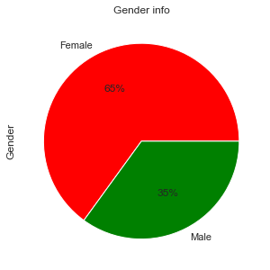

```python
colors = ['red', 'green']
labels = 'Female', 'Male'
medical_data['Gender'].value_counts().plot(kind='pie', title= 'Gender info', labels=labels,colors=colors,autopct='%1.0f%%', figsize=(5,5));
```

Generally , as we can see the number of Females are approximately twice higher than Males

[figure not shown]

```python
absence_appointment= medical_data.groupby('Gender').No_show.value_counts().unstack().plot(kind='bar',width =1,figsize=(12,9), color=['white','blue'])
absence_appointment.set_title("No show rate by Gender")
plt.ylabel("Number of No show and show")
plt.xlabel("Gender of No show and show")
plt.legend(['No_show','show']);
plt.show()
```

The majority of appointment absence was for Female

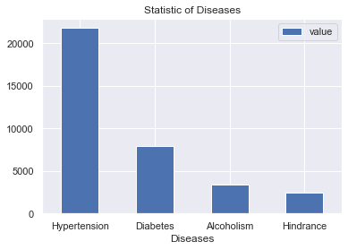

```python
#Which disease does the patients have more than the other
df = pd.DataFrame({'Diseases':[  'Hypertension','Diabetes', 'Alcoholism','Hindrance'],
                    'value':[medical_data.Hypertension.sum(), medical_data.Diabetes.sum(), medical_data.Alcoholism.sum(),medical_data.Hindrance.sum()]})
df.plot.bar(x='Diseases', y='value', rot=0 ,title="Statistic of Diseases")
```

As we can see Hypertension disease has highest value

## 3) What is the effect of sending SMS to the patients ?

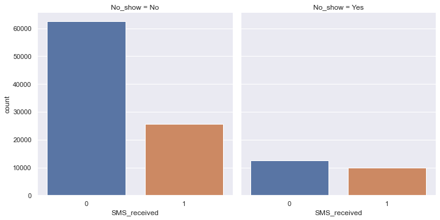

```python
#The effect of sending messages to the patients.
sns.catplot(x="SMS_received", col="No_show",

                data=medical_data, kind="count");
```

## Limitations

As we see there was a negative value regarding age , and data type of two columns were not good so we convert it .